# Median of mean

Arthur TENA

17/04/2024

# Introduction :

Étant donné un échantillon de données, l’estimateur MoM mélange les points de données puis les divise en k groupes de m données. Ensuite, il calcule la moyenne arithmétique de chaque groupe. Enfin, nous calculons la médiane des moyennes arithmétiques résultantes.

Cette technique diminue l’effet des valeurs aberrantes sur l’estimation finale en divisant les données et en ne considérant que la médiane des sous-estimations résultantes.

# Median of mean :

## Codes :

```r
median_of_means <- function(seq, n) {
  if (n > length(seq)) {
    n <- ceiling(length(seq) / 2)
  }
  indic <- rep(1:n, each = floor(length(seq) / n))
  indic <- sample(indic)
  moyennes <- sapply(1:n, function(block) mean(seq[indic == block]))
  return(median(moyennes))
}
```

On améliore un peu l’estimateur en refaisant la même opération plusieurs fois à l’aide de la fonction *replicate* de R l fois et en utilisant la moyenne empirique *mean*.

```r
rob_median_of_means <- function(seq, n, l) {
  res <- replicate(l, median_of_means(seq, n))
  return(mean(res))
}
```

## Exemples :

Nous allons voir dans les exemples plusieurs cas de figure. Un cas de figure ou la moyenne est connue car on utilise les lois usuelles puis un second cas de figure ou les lois ne seront pas définies et donc la moyenne ne sera pas connue.

### Exemples dont la moyenne est connue :

Dans tous nos exmple, nous allons regarder la mediannes des moyennes calculée avec notre fonction, la moyenne à l’aide de la fonction *mean* de R et l’écart quadratique entre les 2 résultats.

[x] N’utilise pas le nombre de blocks optimal  
[ ] Utilise le nombre de block optimal

- Loi gaussienne centrée, de variance $\sigma=3$ en 10 blocks

```r
M=0
population1=rnorm(1000,M,3)
c(median_of_means(population1, 10),mean(population1),(mean(population1) - median_of_means(population1, 10)) ^ 2)
```

```
## [1] -0.208877981 -0.079791603  0.002526647
```

```r
c(rob_median_of_means(population1, 10, 20),mean(population1),(mean(population1) - rob_median_of_means(population1, 10, 20)) ^ 2)
```

```
## [1] -6.862318e-02 -7.979160e-02  9.889402e-06
```

La moyenne est 0 pour une loi normale centrée, on voit que l’erreur quadratique de l’estimateur **median_of_mean** est plus élevée que le deuxième estimateur **rob_median_of_mean**

- Loi gaussienne de moyenne $\mu=4$ et de variance $\sigma=1$ en 10 blocks

```r
population2=rnorm(1000,4,1)
c(median_of_means(population2, 10),mean(population2),(mean(population2) - median_of_means(population2, 10)) ^ 2)
```

```
## [1] 4.040465e+00 4.038895e+00 4.863375e-06
```

```r
c(rob_median_of_means(population2, 10, 20),mean(population2),(mean(population2) - rob_median_of_means(population2, 10, 20)) ^ 2)
```

```
## [1] 4.036428e+00 4.038895e+00 4.162254e-06
```

- Loi de Student à k=5 degré de liberté en 10 blocks

```r
population3=rt(1000, df=5)
c(median_of_means(population3, 10),mean(population3),(mean(population3) - median_of_means(population3, 10)) ^ 2)
```

```
## [1] 0.017566089 0.029887354 0.000131943
```

```r
c(rob_median_of_means(population3, 10, 20),mean(population3),(mean(population3) - rob_median_of_means(population3, 10, 20)) ^ 2)
```

```
## [1] 3.331783e-02 2.988735e-02 2.858371e-06
```

On sait que pour une loi de student de ddl>1, l’espérance est nulle, c’est ce que l’on trouve avec les 2 estimateurs.

[ ] N’utilise pas le nombre de blocks optimal  
[x] Utilise le nombre de block optimal

```r
median_of_means_opt <- function(seq, alpha) {
  n=length(seq)
  k <- abs(trunc(8*log(1/alpha)))
  m <- n/k
  indic <- rep(1:k, each = m)
  moyennes <- sapply(1:k, function(block) mean(seq[indic == block]))
  return(median(moyennes))
}

rob_median_of_means_opt <- function(seq, alpha, l) {
  res <- replicate(l, median_of_means_opt(seq, alpha))
  return(mean(res))
}
```

Ici je cherche le coefficient qui minimisera l’erreur

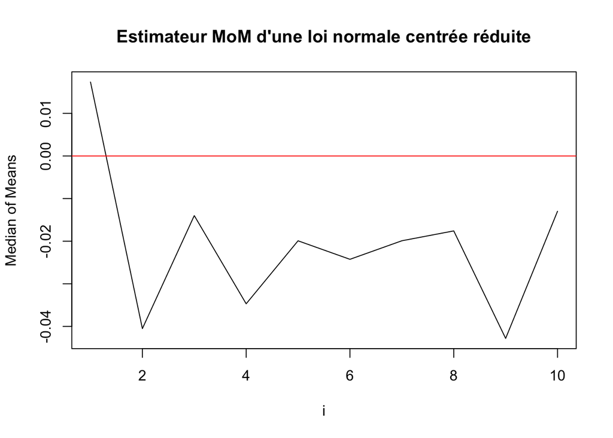

```r
median_of_means_opt2 <- function(alpha) {
  population1=rnorm(1000,0,3)
  n=length(population1)
  vec=c()
  for (i in 1:10){
    k <- abs(trunc(i*log(1/alpha)))
    m <- n/k
    indic <- rep(1:k, each = m)
    moyennes <- sapply(1:k, function(block) mean(population1[indic == block]))
    vec[i]=median(moyennes)
  }
  return(vec)
}

median_of_means_opt3 <- function(seq, alpha, i) {
  n <- length(seq)
  k <- abs(trunc(i * log(1/alpha)))
  m <- n / k
  indic <- rep(1:k, each = m)
  moyennes <- sapply(1:k, function(block) mean(seq[indic == block]))
  return(median(moyennes))
}

population1 <- rnorm(1000, 0, 1)
alpha <- 0.025
i_values <- 1:10
median_values <- sapply(i_values, function(i) median_of_means_opt3(population1, alpha, i))
plot(x = i_values, y = median_values, type = "l", xlab = "i", ylab = "Median of Means", main ="Estimateur MoM d'une loi normale centrée réduite")
abline(h=0, col='red')
```

```r
alpha=2.5
population1=rnorm(1000,0,3)
c(median_of_means_opt(population1, alpha),mean(population1),(mean(population1) - median_of_means_opt(population1, alpha)) ^ 2)
```

```
## [1] -0.0224290404 -0.0033509399  0.0003639739
```

```r
c(rob_median_of_means_opt(population1, alpha, 20),mean(population1),(mean(population1) - rob_median_of_means_opt(population1, alpha, 20)) ^ 2)
```

```
## [1] -0.0224290404 -0.0033509399  0.0003639739
```

On remarque que les 2 estimateurs optiaux donnent les même valeurs.

### Exemples dont la moyenne est inconnue :

[x] N’utilise pas le nombre de blocks optimal  
[ ] Utilise le nombre de block optimal

- sample de valeures entières comprises entre -2 et 10 en 10 blocks

```r
population_rd1=sample(x = -2:10, size = 1000, replace = TRUE, prob=NULL)
c(median_of_means(population_rd1, 10),mean(population_rd1),(mean(population_rd1) - median_of_means(population_rd1, 10)) ^ 2)
```

```
## [1] 4.030000 3.977000 0.001089
```

```r
c(rob_median_of_means(population_rd1, 10, 20),mean(population_rd1),(mean(population_rd1) - rob_median_of_means(population_rd1, 10, 20)) ^ 2)
```

```
## [1] 3.975e+00 3.977e+00 6.250e-08
```

```r
population_rd2=sample(x = seq(-1,1, by=0.001), size = 1000, replace = TRUE, prob=NULL)
c(median_of_means(population_rd2, alpha),mean(population_rd2),(mean(population_rd2) - median_of_means(population_rd2, alpha)) ^ 2)
```

```
## [1] -3.008142e-02 -2.976500e-02  2.464734e-08
```

```r
c(rob_median_of_means(population_rd2, alpha, 20),mean(population_rd2),(mean(population_rd2) - rob_median_of_means(population_rd2, alpha, 20)) ^ 2)
```

```
## [1] -2.967121e-02 -2.976500e-02  1.620424e-09
```

On remarque que l’estimateur de la médianne des moyennes donne des résultats similaires à la fonction **mean**.

[ ] N’utilise pas le nombre de blocks optimal  
[x] Utilise le nombre de block optimal

```r
c(median_of_means_opt(population_rd1, 10),mean(population_rd1),(mean(population_rd1) - median_of_means_opt(population_rd1, 10)) ^ 2)
```

```
## [1] 3.890909091 3.977000000 0.007411645
```

```r
c(rob_median_of_means_opt(population_rd1, 10, 20),mean(population_rd1),(mean(population_rd1) - rob_median_of_means_opt(population_rd1, 10, 20)) ^ 2)
```

```
## [1] 3.890909091 3.977000000 0.007411645
```

```r
c(median_of_means_opt(population_rd2, 10),mean(population_rd2),(mean(population_rd2) - median_of_means_opt(population_rd2, 10)) ^ 2)
```

```
## [1] -3.483916e-02 -2.976500e-02  2.574711e-05
```

```r
c(rob_median_of_means_opt(population_rd2, 10, 20),mean(population_rd2),(mean(population_rd2) - rob_median_of_means_opt(population_rd2, 10, 20)) ^ 2)
```

```
## [1] -3.483916e-02 -2.976500e-02  2.574711e-05
```

```r
population_rd3 <- sample(c(runif(1000, -1, 1), 50), 1000, replace = TRUE)
c(median_of_means_opt(population_rd2, 10),mean(population_rd2),(mean(population_rd2) - median_of_means_opt(population_rd2, 10)) ^ 2)
```

```
## [1] -3.483916e-02 -2.976500e-02  2.574711e-05
```

```r
c(rob_median_of_means_opt(population_rd2, 10, 20),mean(population_rd2),(mean(population_rd2) - rob_median_of_means_opt(population_rd2, 10, 20)) ^ 2)
```

```
## [1] -3.483916e-02 -2.976500e-02  2.574711e-05
```

# Conclusion :

On déduit de tout ça qu’avec l’estimateur de la médianne des moyennes on peut estimer de façon significative la moyenne